# summary

2024-01-24

```r
library(here)
source(here("base","src.R"))
```

Understanding transmission rate is critical to understanding disease dynamics. Zooplankton are a useful model system for studying transmission because transmission is directly related to the rate at which they filter water, which can be measured in the lab. Using this model system, we can study how temperature and resource conditions affect transmission dynamics. We apply experimental data on foraging rate and fungal infections in Daphnia to simple models that can simulate the effects of temperature and resource transmission.

All of these figures and tables are generated from model_fits_viz.Rmd, model_fits_viz_interaction.Rmd, and mod_results.Rmd

# Model 0 - independent model

First, we start with a simple model. In this model, individual daphnia filter water at a constant rate, regardless of size or environmental conditions.

$$\frac{dR}{dt} = -fRS \\$$

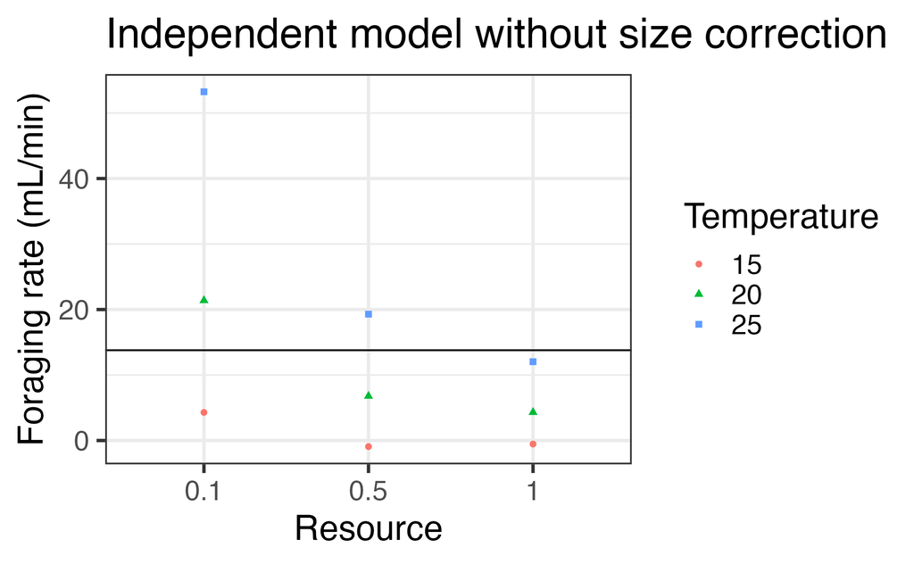

Obviously, not a great fit

# Model 1 - size-corrected

Next, we can improve this slightly by incorporating a size-correction term. However, we still have no flexibility in our ability to incorporate the effects of temperature or resources.

$$\frac{dR}{dt} = -L^{\gamma} fRS\\$$

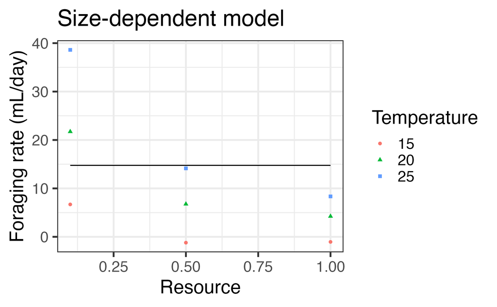

# Model 2 - Temperature-dependent

Here, we incorporate just a temperature-dependence. We switch up the x-axis for this one because this one is only temperature-dependent. If resource was on the x-axis, we would still have a horizontal line.

$$\frac{dR}{dt} = -L^{\gamma}fe^{T_{A}(1/T_{R}-1/T)} RS\\$$

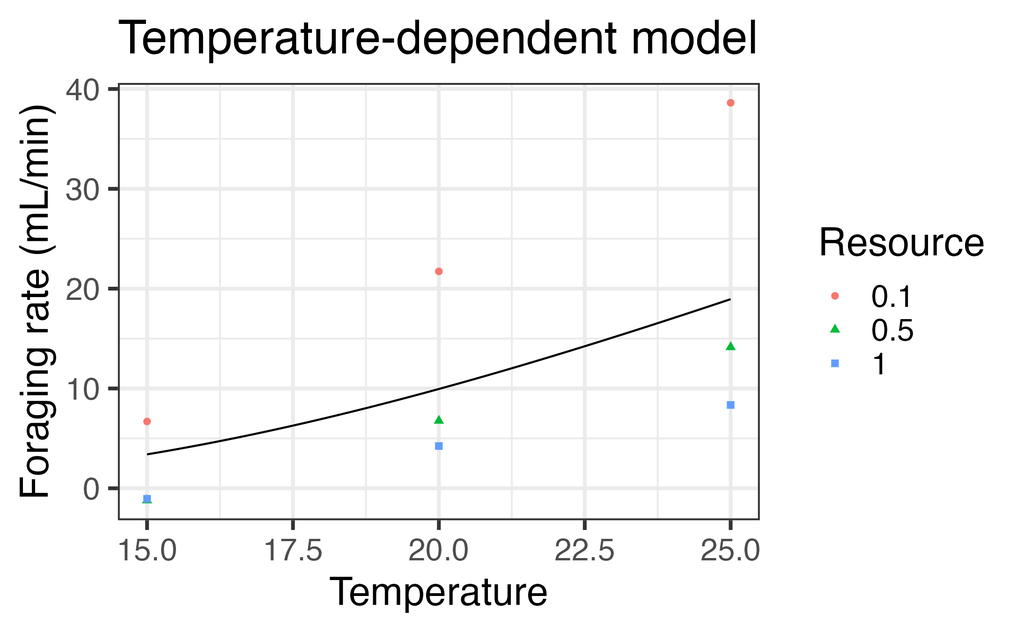

# Model 3 - Resource-dependent

And here we incorporate resource-dependence. If we plotted temperature on the x-axis for this one, then we would get a horizontal line.

$$\frac{dR}{dt} = - \frac{fL^{\gamma}RS}{1 + fL^{\gamma}hR} \\$$

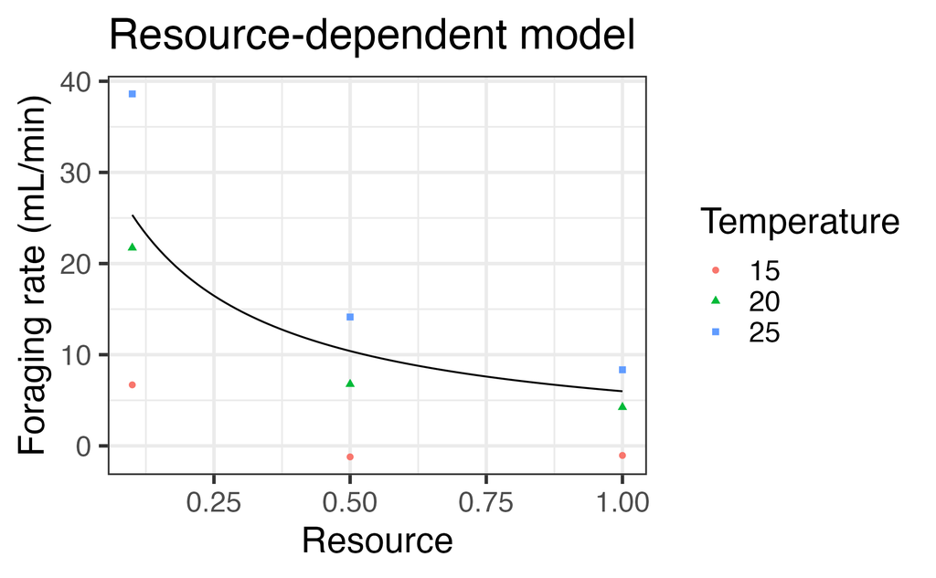

# Model 4 - Temperature and Resource-dependent

Finally, we have incorporated both temperature and resource-dependence. We now have separate lines for each temperature treatment and the foraging rate changes as resource changes. However, this version of the model is still limited because it assumes a constant value for the Arrhenius temperature and the handling time. It is possible that these coefficients change depending on the temperature or resource conditions. The strength of the Arrhenius coefficient and its ability to alter foraging rate may be dependent on the resource availability. Vice versa, the handling time may depend on the temperature. If there is an interaction between these variables, then we can rewrite this model to incorporate those effects.

$$\frac{dR}{dt} = -\frac{fe^{T_{A}(1/T_{R}-1/T)} L^{\gamma}RS}{1 +
fe^{T_{A}(1/T_{R}-1/T)}L^{\gamma}hR} \\$$

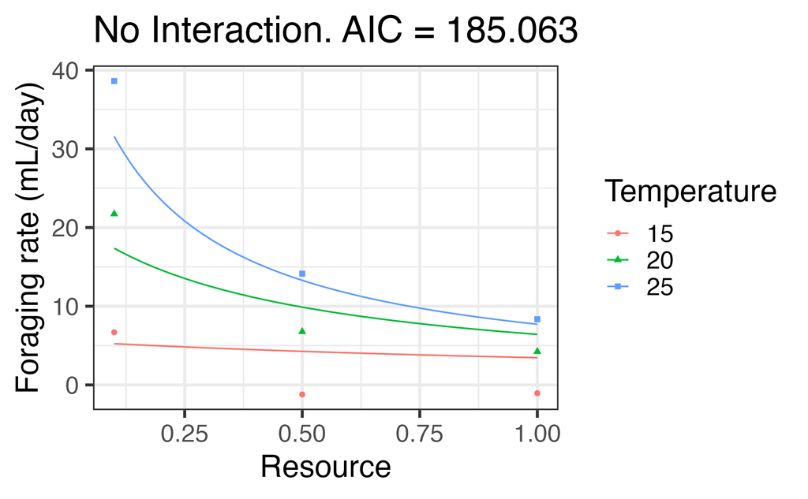

# Model 5b - Resource on Temperature Interaction - Linear

One way that we can do this is by assuming a linear relationship between the Arrhenius temperature and resource concentration. Here, we update the expression for the Arrhenius temperature to vary linearly with resources according to a new parameter, rho.

$$T_{A} = {T_{A}}' + {\rho}R$$

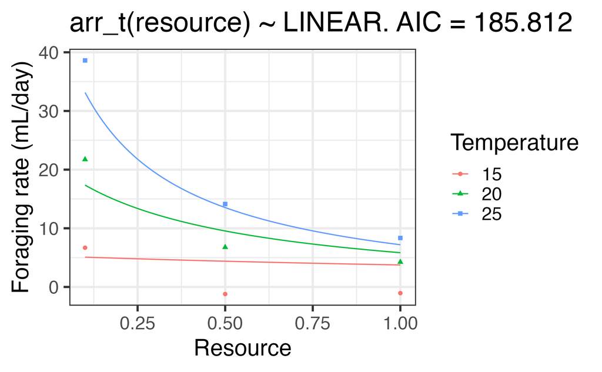

# Model 5c - Resource on Temperature Interaction - Exponential

Another way that we can do this is by assuming an exponential relationship. Here, the Arrhenius temperature is scaled exponentially by resources according to parameter rho.

$$T_{A} = {T_{A}}'e^{{\rho}R}$$

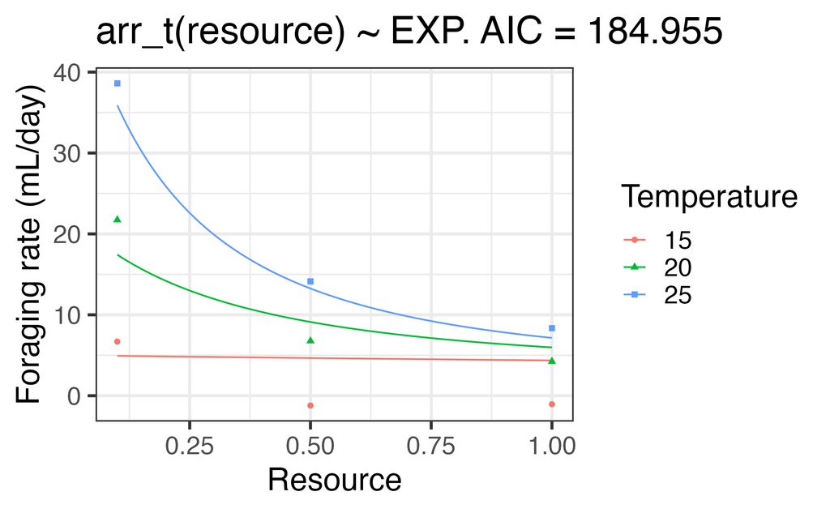

# Model 6b - Temperature on Resource Interaction - Linear

We can then do the same thing with handling time and its relationship with temperature. Here, handling time scales linearly with temperature according to omega.

$$h = h' + {\omega}T$$

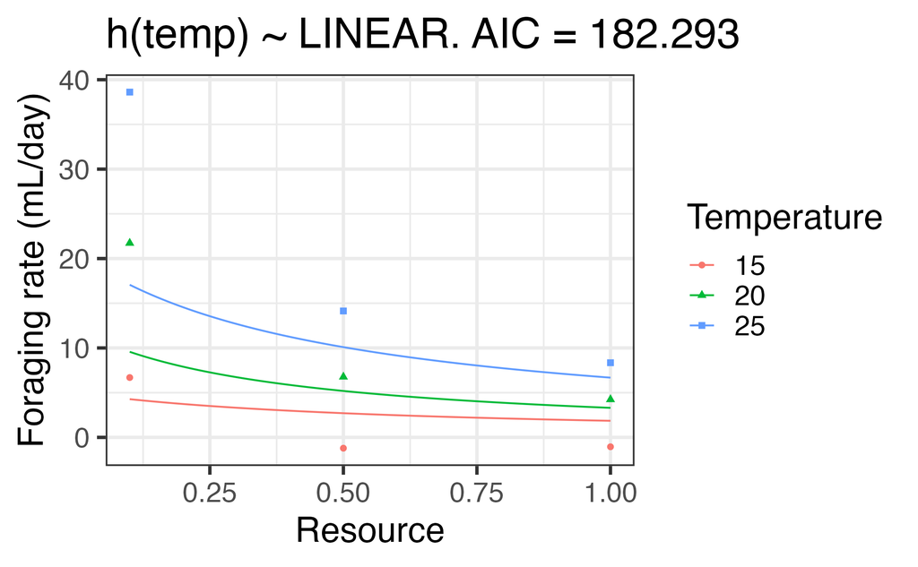

# Model 6c - Temperature on Resource Interaction - Exponential

And here, handling time scales exponentially with temperature according to omega.

$$h = h'e^{{\omega}T}$$

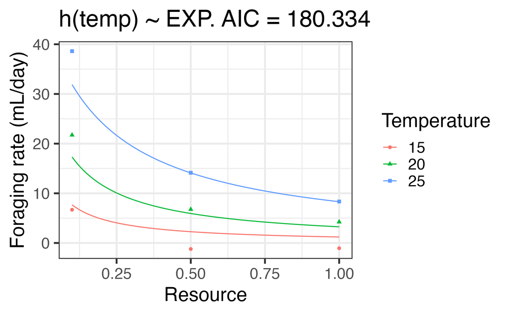

# Model 7b - Full Interaction Model - Linear-Linear

Finally, we can incorporate both of these interactions linearly…

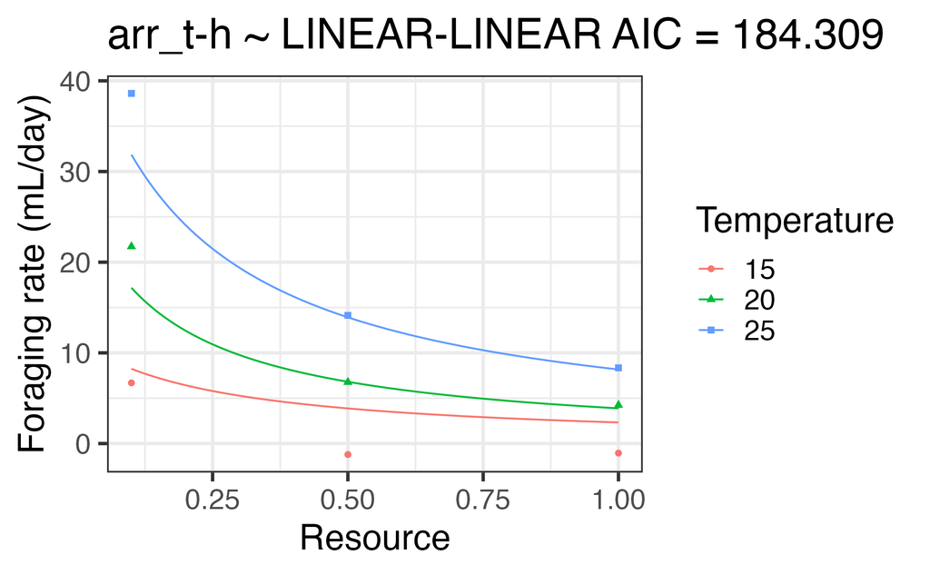

# Model 7c - Full Interaction Model - Exponential-Exponential

… and exponentially.

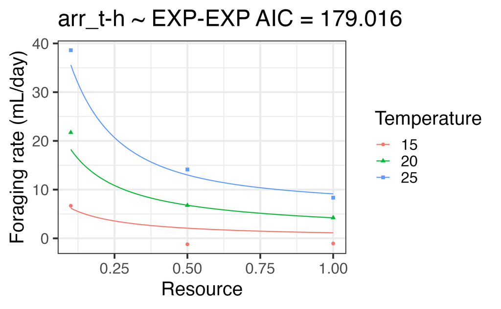

# Model 7d - Full Interaction Model - Linear-Exponential

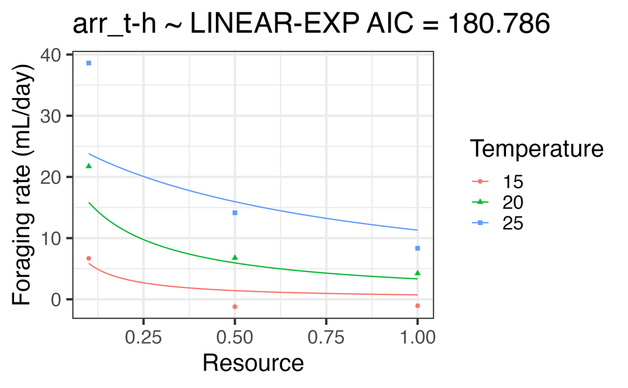

# Model 7e - Full Interaction Model - Exponential-Linear

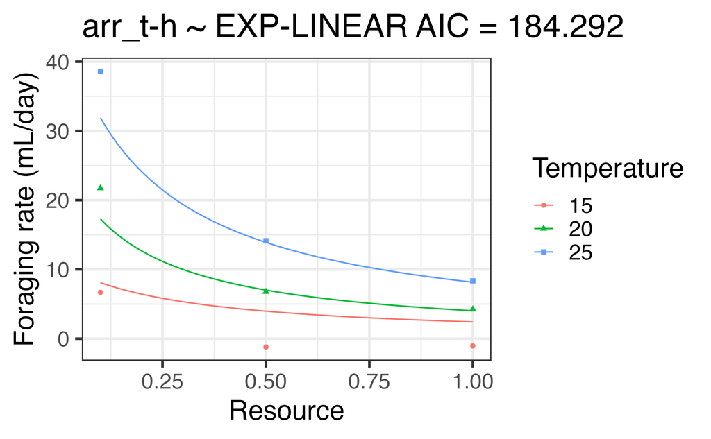

# AIC

Finally, we can check to see how these models compare to each other using AIC. AIC will consider both the number of coefficients used in the model and the likelihood of the model.

```r
readRDS(here("mle/aic_table.rds"))
```

```
##            logLik AIC    dLogLik dAIC   df
## EXP_EXP     -84.5  179.0  137.2     0.0 5
## h(T)~EXP    -86.2  180.3  135.5     1.3 4
## LIN_EXP     -85.4  180.8  136.3     1.8 5
## h(T)~LIN    -87.1  182.3  134.5     3.3 4
## EXP_LIN     -87.1  184.3  134.5     5.3 5
## LIN-LIN     -87.2  184.3  134.5     5.3 5
## arr(R)~EXP  -88.5  185.0  133.2     5.9 4
## full        -89.5  185.1  132.2     6.0 3
## arr(R)~LIN  -88.9  185.8  132.8     6.8 4
## rsc        -134.3  272.7   87.3    93.7 2
## temp       -174.7  353.4   47.0   174.4 2
## size       -193.3  388.6   28.4   209.6 1
## base       -221.7  445.4    0.0   266.4 1
```

## Three best models

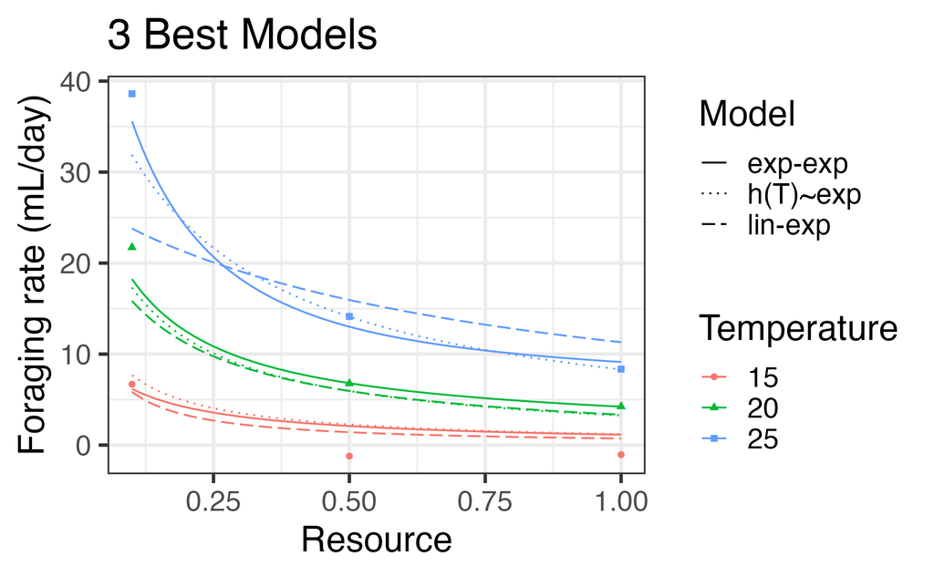

# Parameters

We can also compare how parameters interacted with either condition

# Arrhenius Temperature for model 5

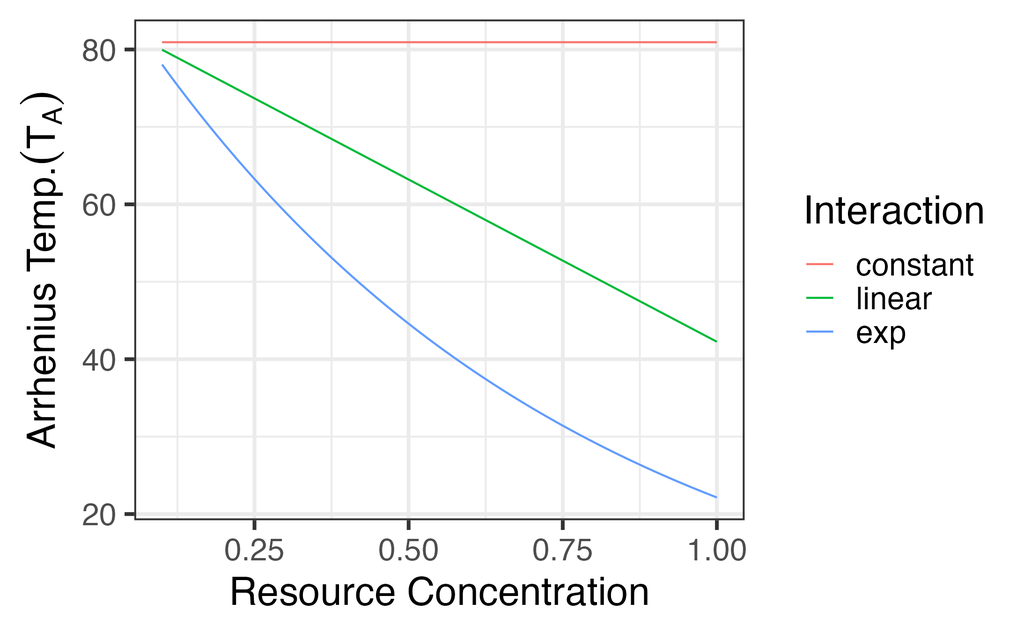

# Handling time for model 6

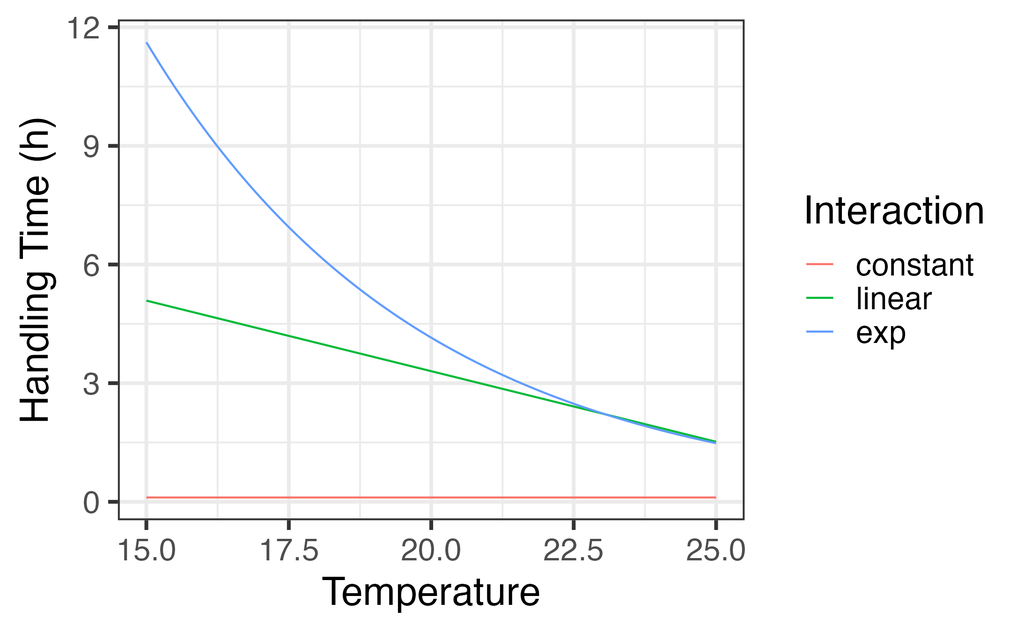

# Arrhenius Temperature for model 7

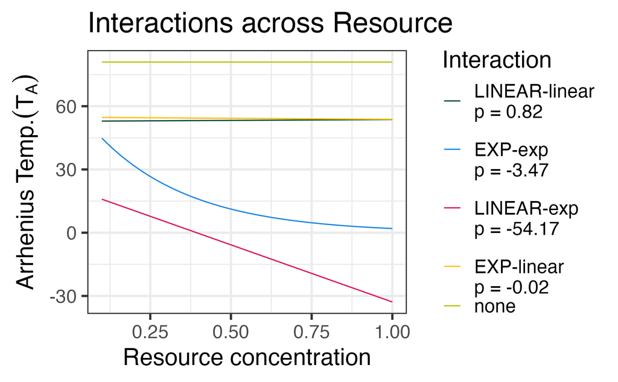

# Handling time for model 7

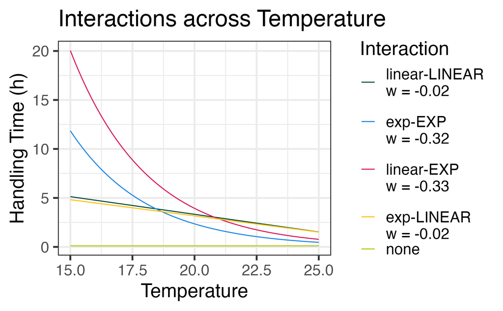